# Intro to R

2022-05-06

```r
print("hello")
```

```
## [1] "hello"
```

## 1. Variables and Classes

Variables are containers for storing data values. A variable is created the moment you first assign a value to it and it will be stored in this container until you assign a new value to it.

```r
x <- 1
number <- 27
words <- "Happy Mothers's Day!"
```

```r
print(x)
```

```
## [1] 1
```

```r
print(number)
```

```
## [1] 27
```

```r
print(words)
```

```
## [1] "Happy Mothers's Day!"
```

```r
print(x + number)
```

```
## [1] 28
```

## Task

1. Assign a value of your name to a new variables **name**
2. And **print** your name

## 2. Data Types

In programming, data type is an important concept.

Variables can store data of different types, and different types can do different things.

R has the following data types built-in by default, in these categories:

- **Numeric Types**: int, float
- **Text Type**: character, factor
- **Dates:** date, POSIXct
- **Boolean Type**: logical
- **Vector Types**: list
- **Data frame Types:** data.frame, tibble

```r
# check for data types
class(x)
```

```
## [1] "numeric"
```

```r
class(words)
```

```
## [1] "character"
```

```r
# check by true/false
is.numeric(x)
```

```
## [1] TRUE
```

```r
is.numeric(words)
```

```
## [1] FALSE
```

```r
# change the data type for x

x <- as.character(x)
print(x) # notice the quotation marks
```

```
## [1] "1"
```

## 3. Data Frames

It’s a way to view data in a spreadsheet format, like in Excel.

```r
# read in data from a csv file
df <- read_csv("data/starbucks_drinkMenu_expanded.csv")
# check the class of the dataframe
class(df)
```

```
## [1] "spec_tbl_df" "tbl_df"      "tbl"         "data.frame"
```

```r
# get the column names
colnames(df)
```

```
##  [1] "category"      "beverage"      "prep"          "calories"
##  [5] "total_fat"     "trans_fat"     "saturated_fat" "sodium"
##  [9] "total_carbs"   "cholesterol"   "fiber"         "sugars"
## [13] "protein"       "vitamin_a"     "vitamin_c"     "calcium"
## [17] "iron"          "caffeine"
```

### In reality, each column is a vector. How do we select for each column?

1. Use the ‘$’ convention
2. Use square brackets

```r
# dollar sign convention
df$category
```

```
##   [1] "Coffee"                            "Coffee"
##   [3] "Coffee"                            "Coffee"
##   [5] "Classic Espresso Drinks"           "Classic Espresso Drinks"
##   [7] "Classic Espresso Drinks"           "Classic Espresso Drinks"
##   [9] "Classic Espresso Drinks"           "Classic Espresso Drinks"
##  [11] "Classic Espresso Drinks"           "Classic Espresso Drinks"
##  [13] "Classic Espresso Drinks"           "Classic Espresso Drinks"
##  [15] "Classic Espresso Drinks"           "Classic Espresso Drinks"
##  [17] "Classic Espresso Drinks"           "Classic Espresso Drinks"
##  [19] "Classic Espresso Drinks"           "Classic Espresso Drinks"
##  [21] "Classic Espresso Drinks"           "Classic Espresso Drinks"
##  [23] "Classic Espresso Drinks"           "Classic Espresso Drinks"
##  [25] "Classic Espresso Drinks"           "Classic Espresso Drinks"
##  [27] "Classic Espresso Drinks"           "Classic Espresso Drinks"
##  [29] "Classic Espresso Drinks"           "Classic Espresso Drinks"
```

[output cut: 106 more lines]

```r
# square brackets
df['category']
```

```
## # A tibble: 242 × 1
##    category
##    <chr>
##  1 Coffee
##  2 Coffee
##  3 Coffee
##  4 Coffee
##  5 Classic Espresso Drinks
##  6 Classic Espresso Drinks
##  7 Classic Espresso Drinks
##  8 Classic Espresso Drinks
##  9 Classic Espresso Drinks
## 10 Classic Espresso Drinks
## # … with 232 more rows
```

### Explore the different categories of beverages in the data

```r
unique(df$category)
```

```
## [1] "Coffee"                            "Classic Espresso Drinks"
## [3] "Signature Espresso Drinks"         "Tazo® Tea Drinks"
## [5] "Shaken Iced Beverages"             "Smoothies"
## [7] "Frappuccino® Blended Coffee"       "Frappuccino® Light Blended Coffee"
## [9] "Frappuccino® Blended Crème"
```

## Task: Check how many different drinks are in the data

```r
unique(df$beverages)
```

[output not shown]

### We can also perform functions on the columns

```r
# What's the most amount of calories in a drink?
max(df$calories)
```

```
## [1] 510
```

```r
# What's the least amount of calories in a drink?
min(df$calories)
```

```
## [1] 0
```

### Task: Find the most amount of sugar in a drink

### Let’s say we want to find the “healthiest” options on the menu. First let’s get an overview of all the variables

```r
summary(df)
```

```
##    category           beverage             prep              calories
##  Length:242         Length:242         Length:242         Min.   :  0.0
##  Class :character   Class :character   Class :character   1st Qu.:120.0
##  Mode  :character   Mode  :character   Mode  :character   Median :185.0
##                                                           Mean   :193.9
##                                                           3rd Qu.:260.0
##                                                           Max.   :510.0
##   total_fat           trans_fat     saturated_fat        sodium
##  Length:242         Min.   :0.000   Min.   :0.0000   Min.   : 0.000
##  Class :character   1st Qu.:0.100   1st Qu.:0.0000   1st Qu.: 0.000
##  Mode  :character   Median :0.500   Median :0.0000   Median : 5.000
##                     Mean   :1.307   Mean   :0.0376   Mean   : 6.364
##                     3rd Qu.:2.000   3rd Qu.:0.1000   3rd Qu.:10.000
##                     Max.   :9.000   Max.   :0.3000   Max.   :40.000
##   total_carbs     cholesterol        fiber            sugars
##  Min.   :  0.0   Min.   : 0.00   Min.   :0.0000   Min.   : 0.00
##  1st Qu.: 70.0   1st Qu.:21.00   1st Qu.:0.0000   1st Qu.:18.00
##  Median :125.0   Median :34.00   Median :0.0000   Median :32.00
##  Mean   :128.9   Mean   :35.99   Mean   :0.8058   Mean   :32.96
##  3rd Qu.:170.0   3rd Qu.:50.75   3rd Qu.:1.0000   3rd Qu.:43.75
##  Max.   :340.0   Max.   :90.00   Max.   :8.0000   Max.   :84.00
##     protein        vitamin_a          vitamin_c           calcium
##  Min.   : 0.000   Length:242         Length:242         Length:242
##  1st Qu.: 3.000   Class :character   Class :character   Class :character
##  Median : 6.000   Mode  :character   Mode  :character   Mode  :character
##  Mean   : 6.979
##  3rd Qu.:10.000
##  Max.   :20.000
##      iron             caffeine
##  Length:242         Length:242
##  Class :character   Class :character
##  Mode  :character   Mode  :character
##
##
##
```

### We see that Vitamin A, Vitamin C, Calcium, and Iron variables are character columns. Let’s explore the *vitamin_a* column

```r
# check class
class(df$vitamin_a)
```

```
## [1] "character"
```

```r
# get a preview
head(df$vitamin_a)
```

```
## [1] "0%"  "0%"  "0%"  "0%"  "10%" "10%"
```

```r
tail(df$vitamin_a)
```

```
## [1] "8%" "6%" "6%" "6%" "4%" "8%"
```

```r
# can you check for unique values?
unique(df$vitamin_a)
```

```
##  [1] "0%"  "10%" "6%"  "15%" "20%" "30%" "25%" "8%"  "4%"  "2%"  "50%"
```

```r
# remove the percent signs
df$vitamin_a <- str_replace(df$vitamin_a, "%", "")


# now look at the unique values in the column
unique(df$vitamin_a)
```

```
##  [1] "0"  "10" "6"  "15" "20" "30" "25" "8"  "4"  "2"  "50"
```

```r
# convert it to a numeric
df$vitamin_a <- as.numeric(df$vitamin_a)


# look at the values now
unique(df$vitamin_a) # notice the removal of the quotation marks
```

```
##  [1]  0 10  6 15 20 30 25  8  4  2 50
```

### Let’s do this for Vitamin C, Calcium, and Iron columns too

```r
# remove percent signs for these columns
df2 <- df %>%
  mutate(
    vitamin_c = str_replace(vitamin_c, "%", ""),
    calcium = str_replace(calcium, "%", ""),
    iron = str_replace(iron, "%", "")
  )
```

### Task: Can you convert Vitamin C, Calcium, and Iron columns into numerics?

```r
# convert vitamin c, calcium, and iron columns into numeric class

df2 <- df2 %>%
  mutate(
    vitamin_c = as.numeric(vitamin_c),
    calcium = as.numeric(calcium) ,
    iron = as.numeric(iron)
  )


# now check the summary again
summary(df2)
```

```
##    category           beverage             prep              calories
##  Length:242         Length:242         Length:242         Min.   :  0.0
##  Class :character   Class :character   Class :character   1st Qu.:120.0
##  Mode  :character   Mode  :character   Mode  :character   Median :185.0
##                                                           Mean   :193.9
##                                                           3rd Qu.:260.0
##                                                           Max.   :510.0
##   total_fat           trans_fat     saturated_fat        sodium
##  Length:242         Min.   :0.000   Min.   :0.0000   Min.   : 0.000
##  Class :character   1st Qu.:0.100   1st Qu.:0.0000   1st Qu.: 0.000
##  Mode  :character   Median :0.500   Median :0.0000   Median : 5.000
##                     Mean   :1.307   Mean   :0.0376   Mean   : 6.364
##                     3rd Qu.:2.000   3rd Qu.:0.1000   3rd Qu.:10.000
##                     Max.   :9.000   Max.   :0.3000   Max.   :40.000
##   total_carbs     cholesterol        fiber            sugars
##  Min.   :  0.0   Min.   : 0.00   Min.   :0.0000   Min.   : 0.00
##  1st Qu.: 70.0   1st Qu.:21.00   1st Qu.:0.0000   1st Qu.:18.00
##  Median :125.0   Median :34.00   Median :0.0000   Median :32.00
##  Mean   :128.9   Mean   :35.99   Mean   :0.8058   Mean   :32.96
##  3rd Qu.:170.0   3rd Qu.:50.75   3rd Qu.:1.0000   3rd Qu.:43.75
##  Max.   :340.0   Max.   :90.00   Max.   :8.0000   Max.   :84.00
##     protein         vitamin_a        vitamin_c          calcium
##  Min.   : 0.000   Min.   : 0.000   Min.   :  0.000   Min.   : 0.00
##  1st Qu.: 3.000   1st Qu.: 4.000   1st Qu.:  0.000   1st Qu.:10.00
##  Median : 6.000   Median : 8.000   Median :  0.000   Median :20.00
##  Mean   : 6.979   Mean   : 9.831   Mean   :  3.649   Mean   :20.76
##  3rd Qu.:10.000   3rd Qu.:15.000   3rd Qu.:  0.000   3rd Qu.:30.00
##  Max.   :20.000   Max.   :50.000   Max.   :100.000   Max.   :60.00
##       iron          caffeine
##  Min.   : 0.000   Length:242
##  1st Qu.: 0.000   Class :character
##  Median : 2.000   Mode  :character
##  Mean   : 7.446
##  3rd Qu.:10.000
##  Max.   :50.000
```

### Now we can create our healthy drinks table by selecting for drinks with these characteristics:

```r
healthy <- df2 %>%
  filter(
    sugars < mean(sugars),
    vitamin_a  == median(vitamin_a),
    vitamin_c == median(vitamin_c)
  )
```

## Let’s visualize the drinks with the most sugar

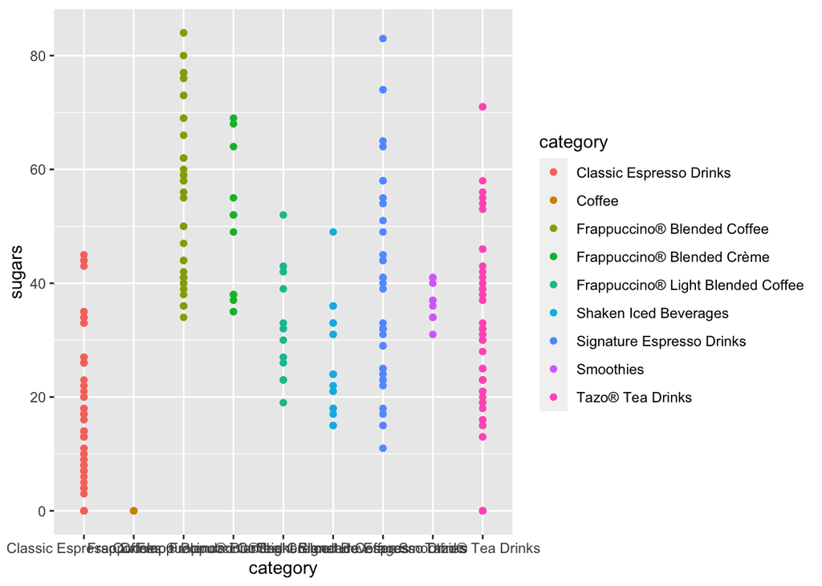

```r
ggplot(df2, aes(x= category, y = sugars, color = category)) +
  geom_point()
```

## Introduce group_by

Let’s create a table that summaries each category by our ‘health’ variables

```r
nutrition <- df2 %>%
  group_by(category) %>%
  summarize(sugars = mean(sugars),
          vitamin_a = mean(vitamin_a),
          vitamin_c = mean(vitamin_c)
          )
```

### Now let’s make a bar chart of the drinks with the highest sugar content

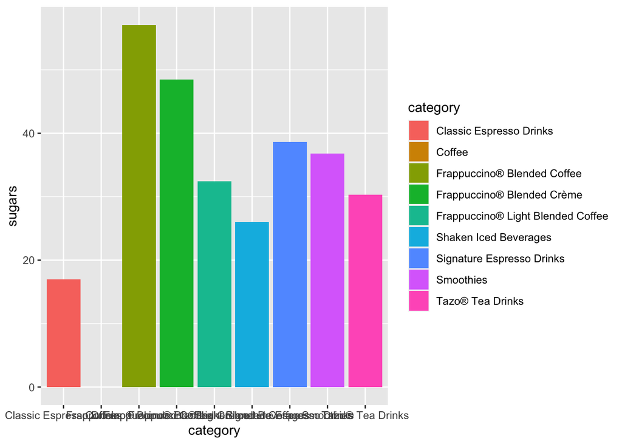

```r
ggplot(nutrition, aes(x = category, y = sugars, fill = category)) +
  geom_bar(stat= "identity") # use "identity" to get the actual value of the column instead of the total number of rows
```

### Task: Can you create a bar chart of the drinks with the highest Vitamin C content?

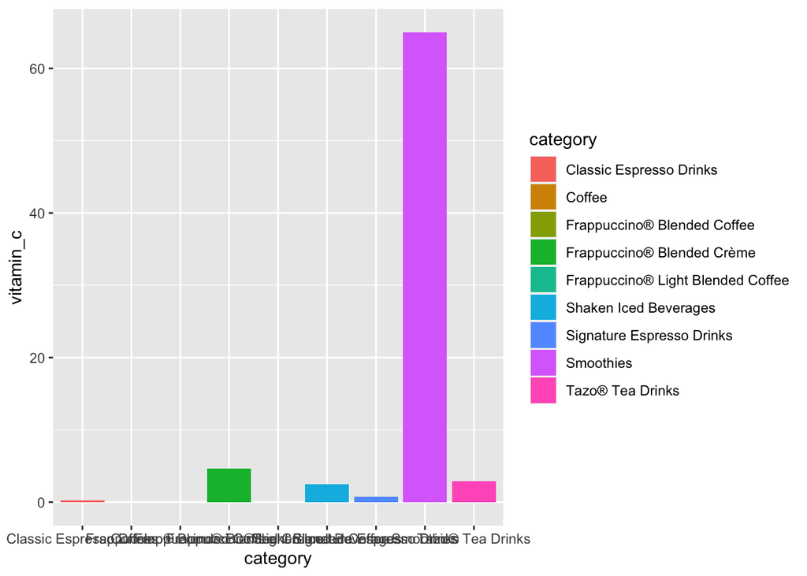

```r
ggplot(nutrition, aes(x = category, y = vitamin_c, fill = category)) +
  geom_bar(stat= "identity")
```

## Add labels and clean up the X axis

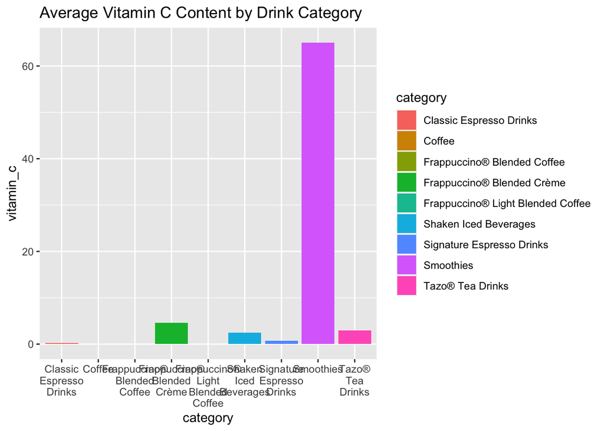

```r
ggplot(nutrition, aes(x = category, y = vitamin_c, fill = category)) +
  geom_bar(stat= "identity") +
  ggtitle("Average Vitamin C Content by Drink Category") +
  scale_x_discrete(labels=function(x){gsub(" ", "\n", nutrition$category)})
```